# How to deal with out-of-memory data

## Pandas + SQL

We use a nearly 10GB dataset containing NYC's 311 complaints since 2010 to demonstrate. The data can be downloaded here: https://data.cityofnewyork.us/Social-Services/311-Service-Requests-from-2010-to-Present/erm2-nwe9. The orginial dataset contains 19.6M records with 41 columns (it is updated daily so you may get a different result by running the code below).

```python
import pandas as pd
from sqlalchemy import create_engine
import datetime as dt
```

We first look at what the observations are like:

```python
display(pd.read_csv('311_Service_Requests_from_2010_to_Present.csv', nrows=2))
```

|  | Unique Key | Created Date | Closed Date | Agency | Agency Name | Complaint Type | Descriptor | Location Type | Incident Zip | Incident Address | ... | Vehicle Type | Taxi Company Borough | Taxi Pick Up Location | Bridge Highway Name | Bridge Highway Direction | Road Ramp | Bridge Highway Segment | Latitude | Longitude | Location |
| --- | --- | --- | --- | --- | --- | --- | --- | --- | --- | --- | --- | --- | --- | --- | --- | --- | --- | --- | --- | --- | --- |
| 0 | 34887213 | 11/29/2016 11:17:07 PM | 11/30/2016 02:32:46 AM | NYPD | New York City Police Department | Noise - Residential | Loud Music/Party | Residential Building/House | 10472 | 1237 ELDER AVENUE | ... | NaN | NaN | NaN | NaN | NaN | NaN | NaN | 40.829622 | -73.879425 | (40.82962235195856, -73.87942543545233) |
| 1 | 34887215 | 11/29/2016 07:41:03 AM | 12/01/2016 11:38:17 AM | HPD | Department of Housing Preservation and Develop... | WATER LEAK | SLOW LEAK | RESIDENTIAL BUILDING | 11201 | 86 BERGEN STREET | ... | NaN | NaN | NaN | NaN | NaN | NaN | NaN | 40.686511 | -73.989940 | (40.686510876191235, -73.98994003433391) |

2 rows × 41 columns

If we try to load the whole dataset at once, it will raise the memory error after minutes' of running:

```python
%timeit dt311 = pd.read_csv('311_Service_Requests_from_2010_to_Present.csv') # memory error
```

Thus,we need to read the dataset by trunks and select the useful subset we are interested in at the same time.

```python
disk_engine = create_engine('sqlite:///NYC_311.db')
start = dt.datetime.now()
chunksize = 100
j = 0
index_start = 1

for df in pd.read_csv('311_Service_Requests_from_2010_to_Present.csv', chunksize=chunksize, iterator=True, encoding='utf-8', header=0):# head=0 specifies the number of the row where the header is located
    df = df.rename(columns={c: c.replace(' ', '') for c in df.columns}) # Remove spaces from columns

    df['CreatedDate'] = pd.to_datetime(df['CreatedDate'], errors='coerce', infer_datetime_format=True) # Convert to datetimes
    df['ClosedDate'] = pd.to_datetime(df['ClosedDate'], errors='coerce', infer_datetime_format=True)

    df.index += index_start

    # Remove the un-interesting columns
    columns = ['Agency', 'CreatedDate', 'ClosedDate', 'ComplaintType', 'Descriptor',
               'CreatedDate', 'ClosedDate', 'TimeToCompletion', 'City']

    for c in df.columns:
        if c not in columns:
            df = df.drop(c, axis=1)

    j+=1
    if j%12000 == 0:
        print('{} seconds: completed {} rows'.format((dt.datetime.now() - start).seconds, j*chunksize))

    df.to_sql('data', disk_engine, if_exists='append') # Connect the trunk to the database
    index_start = df.index[-1] + 1
```

```
1000 seconds: completed 1200000 rows
2011 seconds: completed 2400000 rows
2936 seconds: completed 3600000 rows
3844 seconds: completed 4800000 rows
4734 seconds: completed 6000000 rows
5639 seconds: completed 7200000 rows
7468 seconds: completed 8400000 rows
8515 seconds: completed 9600000 rows
9508 seconds: completed 10800000 rows
10428 seconds: completed 12000000 rows
11332 seconds: completed 13200000 rows
12230 seconds: completed 14400000 rows
13126 seconds: completed 15600000 rows
14001 seconds: completed 16800000 rows
14853 seconds: completed 18000000 rows
15925 seconds: completed 19200000 rows
```

Even so, the reading procedure takes more than 4 hours to complete. The good news is, we can finally read the data in and exclude the features we are not interested in. The databased is saved as `NYC_311.db`(about 1 GB) and can be connected using SQL directly in the future.

We first check how many records are there in total.

```python
pd.read_sql_query('SELECT COUNT(*) as `num_of_records`'
                 'FROM data ', disk_engine)
```

[output not shown]

We can then analyze the dataset using the database we acquired using SQLite. For example, we can investigate which department receives the most complaints:

```python
complaints_by_agency = pd.read_sql_query('SELECT Agency, COUNT(*) as `num_complaints`'
                       'FROM data '
                       'GROUP BY Agency '
                       'ORDER BY -num_complaints ' # in a descending order
                       'LIMIT 10', disk_engine) # notice there is space at the end of each line of SQL command
```

Then we use `matplotlib` module to visualize it:

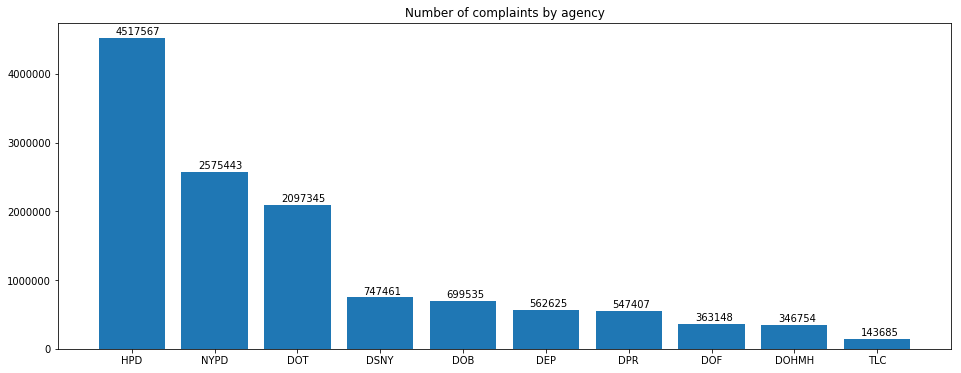

```python
import matplotlib.pyplot as plt
ind = range(complaints_by_agency.shape[0])
plt.figure(figsize=(16,6))
plt.bar(x=ind,height=complaints_by_agency['num_complaints'])
for k in ind:
    plt.text(k-0.2, complaints_by_agency['num_complaints'][k]+50000,str(complaints_by_agency['num_complaints'][k]))
plt.title('Number of complaints by agency')
plt.xticks(ind,complaints_by_agency['Agency'])
plt.show()
```

We can see that Housing and Development Dept receives the most complaints.

We can also investigate what are the most common complaints:

```python
most_common_complaints = pd.read_sql_query('SELECT ComplaintType, COUNT(*) as `num_complaints` '
                       'FROM data '
                       'GROUP BY `ComplaintType` '
                       'ORDER BY -num_complaints LIMIT 10', disk_engine)
```

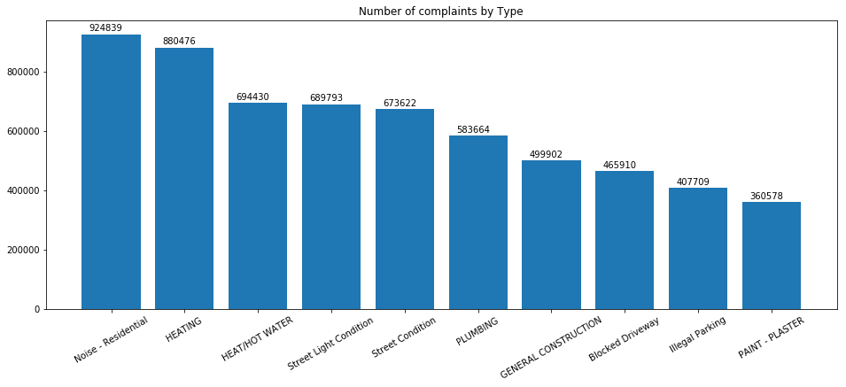

```python
ind = range(most_common_complaints.shape[0])
plt.figure(figsize=(16,6))
plt.bar(x=ind,height=most_common_complaints['num_complaints'])
for k in ind:
    plt.text(k-0.3, most_common_complaints['num_complaints'][k]+10000,str(most_common_complaints['num_complaints'][k]))
plt.title('Number of complaints by Type')
plt.xticks(ind,most_common_complaints['ComplaintType'], rotation=30)
plt.show()
```

We see that the Noise issue is the most common complaints.

# Save your memory by specifying the datatype

This part of the tutorial is inspired by the post https://www.dataquest.io/blog/pandas-big-data/.

We now go back to the Airline on-time performance data. We first load the dataset to pandas dataframe.

```python
tic = dt.datetime.now()
DT_panda = pd.read_csv('Airline2008.csv',header=0)
toc = dt.datetime.now()
print(toc-tic)
```

```
0:00:19.415853
```

Since we are going to check the size of the memory a lot, so we create a function and check the size of the dataset first.

```python
def mem_usage(pandas_obj):
    if isinstance(pandas_obj,pd.DataFrame):
        usage_b = pandas_obj.memory_usage(deep=True).sum()
    else: # we assume if not a df it's a series
        usage_b = pandas_obj.memory_usage(deep=True)
    usage_mb = usage_b / 1024 ** 2 # convert bytes to megabytes
    return "{:03.2f} MB".format(usage_mb)

print(mem_usage(DT_panda))
print(DT_panda.shape)
```

```
3116.65 MB
(7009728, 29)
```

We futher investigate the datatypes of the dataframe.

```python
DT_panda.info()
```

```
<class 'pandas.core.frame.DataFrame'>
RangeIndex: 7009728 entries, 0 to 7009727
Data columns (total 29 columns):
Year                 int64
Month                int64
DayofMonth           int64
DayOfWeek            int64
DepTime              float64
CRSDepTime           int64
ArrTime              float64
CRSArrTime           int64
UniqueCarrier        object
FlightNum            int64
TailNum              object
ActualElapsedTime    float64
CRSElapsedTime       float64
AirTime              float64
ArrDelay             float64
DepDelay             float64
Origin               object
Dest                 object
Distance             int64
TaxiIn               float64
TaxiOut              float64
Cancelled            int64
CancellationCode     object
Diverted             int64
CarrierDelay         float64
WeatherDelay         float64
NASDelay             float64
SecurityDelay        float64
LateAircraftDelay    float64
dtypes: float64(14), int64(10), object(5)
memory usage: 1.5+ GB
```

```python
DT_panda.head()
```

|  | Year | Month | DayofMonth | DayOfWeek | DepTime | CRSDepTime | ArrTime | CRSArrTime | UniqueCarrier | FlightNum | ... | TaxiIn | TaxiOut | Cancelled | CancellationCode | Diverted | CarrierDelay | WeatherDelay | NASDelay | SecurityDelay | LateAircraftDelay |
| --- | --- | --- | --- | --- | --- | --- | --- | --- | --- | --- | --- | --- | --- | --- | --- | --- | --- | --- | --- | --- | --- |
| 0 | 2008 | 1 | 3 | 4 | 2003.0 | 1955 | 2211.0 | 2225 | WN | 335 | ... | 4.0 | 8.0 | 0 | NaN | 0 | NaN | NaN | NaN | NaN | NaN |
| 1 | 2008 | 1 | 3 | 4 | 754.0 | 735 | 1002.0 | 1000 | WN | 3231 | ... | 5.0 | 10.0 | 0 | NaN | 0 | NaN | NaN | NaN | NaN | NaN |
| 2 | 2008 | 1 | 3 | 4 | 628.0 | 620 | 804.0 | 750 | WN | 448 | ... | 3.0 | 17.0 | 0 | NaN | 0 | NaN | NaN | NaN | NaN | NaN |
| 3 | 2008 | 1 | 3 | 4 | 926.0 | 930 | 1054.0 | 1100 | WN | 1746 | ... | 3.0 | 7.0 | 0 | NaN | 0 | NaN | NaN | NaN | NaN | NaN |
| 4 | 2008 | 1 | 3 | 4 | 1829.0 | 1755 | 1959.0 | 1925 | WN | 3920 | ... | 3.0 | 10.0 | 0 | NaN | 0 | 2.0 | 0.0 | 0.0 | 0.0 | 32.0 |

5 rows × 29 columns

By looking at the first few records of the dataframe, we may find that a lot of memory space is actually wasted. For example, `int64` can save values from (-9,223,372,036,854,775,808 to +9,223,372,036,854,775,807) or ($-2^{64}$ to $2^{64}-1$) and uses 8 bytes. Obviously, it is too much to store the "Year" column. Instead `int16` ranges from (-32,768 to +32,767) or ($-2^{16}$ to $2^{16}-1$) is quite enough for it and uses only 2 bytes. It inspires us to transform the data to a "proper" data type that uses as little memory as possible.

Fortunatelly, `pd.to_numeric` offers an option `downcast`to detect the least possible datatype to store the data **automatically**. Here is the description from the documentation:

> **downcast** : {'integer', 'signed', 'unsigned', 'float'} , default None If not None, and if the data has been successfully cast to a numerical dtype (or if the data was numeric to begin with), downcast that resulting data to the smallest numerical dtype possible according to the following rules:
> - 'integer' or 'signed': smallest signed int dtype (min.: np.int8)
>   - 'unsigned': smallest unsigned int dtype (min.: np.uint8)
>   - 'float': smallest float dtype (min.: np.float32)

Let's investigate its effect on each datatype one by one. First,we look at the integer type.

```python
DT_int = DT_panda.select_dtypes(include=['int64'])
converted_int = DT_int.apply(pd.to_numeric, downcast='unsigned')

print(mem_usage(DT_int))
print(mem_usage(converted_int))
```

```
534.80 MB
100.28 MB
```

Since all the integer type data in the dataset are positive, we can downcast them to unsigned integer to save the memory to a maximum extent. In this way, we can save the memory space by ~80%. Following is a summary table of what datatype each variable is transformed to.

```python
compare_int = pd.concat([DT_int.dtypes, converted_int.dtypes], axis=1)
compare_int.columns = ['before','after']
display(compare_int)
compare_int.apply(pd.Series.value_counts)
```

|  | before | after |
| --- | --- | --- |
| Year | int64 | uint16 |
| Month | int64 | uint8 |
| DayofMonth | int64 | uint8 |
| DayOfWeek | int64 | uint8 |
| CRSDepTime | int64 | uint16 |
| CRSArrTime | int64 | uint16 |
| FlightNum | int64 | uint16 |
| Distance | int64 | uint16 |
| Cancelled | int64 | uint8 |
| Diverted | int64 | uint8 |

|  | before | after |
| --- | --- | --- |
| uint8 | NaN | 5.0 |
| uint16 | NaN | 5.0 |
| int64 | 10.0 | NaN |

Next, we look at the float type:

```python
DT_float = DT_panda.select_dtypes(include=['float64'])
converted_float = DT_float.apply(pd.to_numeric, downcast='float')

print(mem_usage(DT_float))
print(mem_usage(converted_float))

compare_float = pd.concat([DT_float.dtypes, converted_float.dtypes], axis=1)
compare_float.columns = ['before','after']
display(compare_float)
compare_float.apply(pd.Series.value_counts)
```

```
748.72 MB
374.36 MB
```

|  | before | after |
| --- | --- | --- |
| DepTime | float64 | float32 |
| ArrTime | float64 | float32 |
| ActualElapsedTime | float64 | float32 |
| CRSElapsedTime | float64 | float32 |
| AirTime | float64 | float32 |
| ArrDelay | float64 | float32 |
| DepDelay | float64 | float32 |
| TaxiIn | float64 | float32 |
| TaxiOut | float64 | float32 |
| CarrierDelay | float64 | float32 |
| WeatherDelay | float64 | float32 |
| NASDelay | float64 | float32 |
| SecurityDelay | float64 | float32 |
| LateAircraftDelay | float64 | float32 |

|  | before | after |
| --- | --- | --- |
| float32 | NaN | 14.0 |
| float64 | 14.0 | NaN |

It can be seen that all the `float64` type has been transformed to `float32`, which saves about half the space for us.

Lastly, lets's look at the object type. `pandas` use this type to store string values.The basic idea is to code the strings into different categories so that we can just store integers and a mapping dictionary instead of the original strings.

The following is a summary of the unique strings of each object.

```python
DT_obj = DT_panda.select_dtypes(include='object').copy()
DT_obj.describe()
```

|  | UniqueCarrier | TailNum | Origin | Dest | CancellationCode |
| --- | --- | --- | --- | --- | --- |
| count | 7009728 | 6926363 | 7009728 | 7009728 | 137434 |
| unique | 20 | 5373 | 303 | 304 | 4 |
| top | WN | N476HA | ATL | ATL | B |
| freq | 1201754 | 4701 | 414513 | 414521 | 54904 |

We see that `CancellationCode` has only 4 unique values. We take it as an example to see how much memory we can save by transforming it to category.

```python
cc = DT_panda['CancellationCode']
display(cc.unique())

cc_cat = cc.astype('category')
display(cc_cat.unique())
cc_cat.unique().codes
```

```
array([nan, 'A', 'C', 'B', 'D'], dtype=object)
```

```
[NaN, A, C, B, D]
Categories (4, object): [A, C, B, D]
```

```
array([-1,  0,  1,  2,  3], dtype=int8)
```

A quick comment here: during transformation, we see `'A','C','B','D'` is coded as `0,1,2,3` and `nan` is coded as `-1`. Now let's check the size before and after.

```python
print(mem_usage(cc))
print(mem_usage(cc_cat))
```

```
217.85 MB
6.69 MB
```

Wow! That's a huge saving!

Before we apply this method to the whole dataset, there is a sidenote you need to pay attention to. Since the `categorical` column stores all of the raw string values in addition to the integer category codes, it will take more storage if we transform an object series with more than 50% unique values. Thus, we need to check each column before we transform them:

```python
converted_obj = pd.DataFrame()
for col in DT_obj.columns:
    num_unique_values = len(DT_obj[col].unique())
    num_total_values = len(DT_obj[col])
    if num_unique_values/ num_total_values < 0.5:
        converted_obj.loc[:,col] = DT_obj[col].astype('category')
    else:
        converted_obj.loc[:,col] = DT_obj[col]
```

We compare the size agian:

```python
print(mem_usage(DT_obj))
print(mem_usage(converted_obj))
```

```
1833.13 MB
54.02 MB
```

Now let's try to save the memory by predetermine the datatype the first time reading in the data.

```python
predetermined_dtypes = {'Year': 'uint16',
 'Month': 'uint8',
 'DayofMonth': 'uint8',
 'DayOfWeek': 'uint8',
 'CRSDepTime': 'uint16',
 'CRSArrTime': 'uint16',
 'FlightNum': 'uint16',
 'Distance': 'uint16',
 'Cancelled': 'uint8',
 'Diverted': 'uint8',
 'DepTime': 'float32',
 'ArrTime': 'float32',
 'ActualElapsedTime': 'float32',
 'CRSElapsedTime': 'float32',
 'AirTime': 'float32',
 'ArrDelay': 'float32',
 'DepDelay': 'float32',
 'TaxiIn': 'float32',
 'TaxiOut': 'float32',
 'CarrierDelay': 'float32',
 'WeatherDelay': 'float32',
 'NASDelay': 'float32',
 'SecurityDelay': 'float32',
 'LateAircraftDelay': 'float32',
 'UniqueCarrier': 'category',
 'TailNum': 'category',
 'Origin': 'category',
 'Dest': 'category',
 'CancellationCode': 'category'}

tic = dt.datetime.now()
DT_optimized = pd.read_csv('Airline2008.csv', dtype= predetermined_dtypes)
toc = dt.datetime.now()
print(toc - tic)
print(mem_usage(DT_optimized))
DT_optimized.head()
```

```
0:00:27.570619
528.65 MB
```

|  | Year | Month | DayofMonth | DayOfWeek | DepTime | CRSDepTime | ArrTime | CRSArrTime | UniqueCarrier | FlightNum | ... | TaxiIn | TaxiOut | Cancelled | CancellationCode | Diverted | CarrierDelay | WeatherDelay | NASDelay | SecurityDelay | LateAircraftDelay |
| --- | --- | --- | --- | --- | --- | --- | --- | --- | --- | --- | --- | --- | --- | --- | --- | --- | --- | --- | --- | --- | --- |
| 0 | 2008 | 1 | 3 | 4 | 2003.0 | 1955 | 2211.0 | 2225 | WN | 335 | ... | 4.0 | 8.0 | 0 | NaN | 0 | NaN | NaN | NaN | NaN | NaN |
| 1 | 2008 | 1 | 3 | 4 | 754.0 | 735 | 1002.0 | 1000 | WN | 3231 | ... | 5.0 | 10.0 | 0 | NaN | 0 | NaN | NaN | NaN | NaN | NaN |
| 2 | 2008 | 1 | 3 | 4 | 628.0 | 620 | 804.0 | 750 | WN | 448 | ... | 3.0 | 17.0 | 0 | NaN | 0 | NaN | NaN | NaN | NaN | NaN |
| 3 | 2008 | 1 | 3 | 4 | 926.0 | 930 | 1054.0 | 1100 | WN | 1746 | ... | 3.0 | 7.0 | 0 | NaN | 0 | NaN | NaN | NaN | NaN | NaN |
| 4 | 2008 | 1 | 3 | 4 | 1829.0 | 1755 | 1959.0 | 1925 | WN | 3920 | ... | 3.0 | 10.0 | 0 | NaN | 0 | 2.0 | 0.0 | 0.0 | 0.0 | 32.0 |

5 rows × 29 columns

Recall that the original dataframe uses 3GB memory and by predetermining the datatype, we cut down the memory usage by **83%**! The method allows us to read larger dataset with limited available memory at an acceptable extra cost of running time.

```python
print(mem_usage(DT_panda))
```

```
3116.65 MB
```

# Parallel Computing using `joblib`

`joblib` is a module develped by the same team that develops `scikit learn`. It is based on `multiprocessing` module but provides more powerful and flexible methods to make your computing parallel. Let's start with a toy example first:

```python
from joblib import Parallel, delayed
import numpy as np
[np.power(i,2) for i in range(10)]
```

```
[0, 1, 4, 9, 16, 25, 36, 49, 64, 81]
```

To parallelize it, you just need to modify the syntax by a little bit using `Parallel` and `delayed`.

```python
Parallel(n_jobs=4)(delayed(np.power)(i,2) for i in range(10))
```

```
[0, 1, 4, 9, 16, 25, 36, 49, 64, 81]
```

Here we specify 4 workers to do the job simultaneously and wrap the function we want to excecute by `delayed`.

What about multiple input and multiple output? `Parallel` will collect the returns of the function into a list.

```python
num_pair = [(1,2), (2,3), (0,5)]
def foo(a,b):
    return a**2, b**2
Parallel(n_jobs=4)(delayed(foo)(i,j) for i,j in num_pair)
```

```
[(1, 4), (4, 9), (0, 25)]
```

Next, let's try the bootstrap example we've already seen using R. First, we load the Iris data and subset only one feature (sepal length) of the data.

```python
from sklearn.datasets import load_iris
data = load_iris()
subset = data.target != 0
X = data.data[subset,0] # sepal length
Y = data.target[subset]
```

```python
from sklearn.linear_model import LogisticRegression
def booti(i, X, Y):
    np.random.seed(i)
    ind = np.random.choice(range(X.shape[0]), 100, replace=True)
    clf = LogisticRegression(random_state=i, solver='lbfgs').fit(X[ind].reshape([-1,1]), Y[ind])
    return np.vstack((clf.intercept_, clf.coef_))
```

```python
import time
n_sim = 10000
tic = time.time()
res_loop = [booti(i, X, Y) for i in range(n_sim)]
toc = time.time()
print("Sequential bootstraping for %d times costs %2.3f seconds\n" %(n_sim, toc-tic))
np.hstack((res_loop[:3]))
```

```
Sequential bootstraping for 10000 times costs 19.935 seconds
```

```
array([[-12.62095792,  -9.43895749, -12.75926784],
       [  1.99107085,   1.47326895,   2.07603253]])
```

Next, we try to parallelize it to see if we can have some speed gain.

```python
n_jobs = 4
tic = time.time()
res_par = Parallel(n_jobs, verbose=0)(delayed(booti)(i, X, Y) for i in range(n_sim))
toc = time.time()
print("Parrellel bootstraping for %d times on %d workers costs %2.3f seconds\n" %(n_sim, n_jobs,toc-tic))
np.hstack((res_par[:3]))
```

```
Parrellel bootstraping for 10000 times on 4 workers costs 8.729 seconds
```

```
array([[-12.62095792,  -9.43895749, -12.75926784],
       [  1.99107085,   1.47326895,   2.07603253]])
```

You can enable `verbose` option to output the detailed running information. The larger value `verbose` is, the more frequent the middle step information will be printed:

```python
foo = Parallel(n_jobs, verbose=5)(delayed(booti)(i, X, Y) for i in range(n_sim))
```

```
[Parallel(n_jobs=4)]: Using backend LokyBackend with 4 concurrent workers.
[Parallel(n_jobs=4)]: Done  52 tasks      | elapsed:    0.0s
[Parallel(n_jobs=4)]: Done 6136 tasks      | elapsed:    4.3s
[Parallel(n_jobs=4)]: Done 10000 out of 10000 | elapsed:    8.1s finished
```

Another useful trick is to put the data into a memmap format. A memory mapped file is just a chunk of memory in your program whose bytes are accessible by more than one process. One reason to do that is to save the "overhead" time. The other reason is to avoid replicating the data for too many times. It is extremely useful when you data is too big and the memory can't hold so many copies of the same data.

```python
import os
from joblib import load, dump
temp_folder = './joblib_memmap'
try:
    os.mkdir(temp_folder)
except FileExistsError:
    pass
disk_X = os.path.join(temp_folder, 'X.mmap')
dump(X, disk_X)
disk_Y = os.path.join(temp_folder, 'Y.mmap')
dump(Y, disk_Y)
```

```
['./joblib_memmap\\Y.mmap']
```

```python
n_sim = 100000
X_mmap = load(disk_X,mmap_mode='r')
Y_mmap = load(disk_Y,mmap_mode='r')
tic = time.time()
res_par_mmap = Parallel(n_jobs, verbose=0)(delayed(booti)(i, X_mmap, Y_mmap) for i in range(n_sim))
toc = time.time()
print("Parrellel bootstraping for %d times on %d workers costs %2.3f seconds\n" %(n_sim, n_jobs,toc-tic))
np.hstack((res_par_mmap[:3]))
```

```
Parrellel bootstraping for 100000 times on 4 workers costs 94.932 seconds
```

```
array([[-12.62095792,  -9.43895749, -12.75926784],
       [  1.99107085,   1.47326895,   2.07603253]])
```

```python
n_sim = 100000
tic = time.time()
res_par = Parallel(n_jobs, verbose=0)(delayed(booti)(i, X, Y) for i in range(n_sim))
toc = time.time()
print("Parrellel bootstraping for %d times on %d workers costs %2.3f seconds\n" %(n_sim, n_jobs,toc-tic))
np.hstack((res_par_mmap[:3]))
```

```
Parrellel bootstraping for 100000 times on 4 workers costs 82.176 seconds
```

```
array([[-12.62095792,  -9.43895749, -12.75926784],
       [  1.99107085,   1.47326895,   2.07603253]])
```

# Web Scraping using `Beautiful Soup`

This part is inspired by https://www.digitalocean.com/community/tutorials/how-to-scrape-web-pages-with-beautiful-soup-and-python-3. We are going to collect all the artist names listed on the webpage together with their links.

Before you scrape, always check if they have a **public API** first. For example, Yelp and Twitter have their data available in a nice format. The next thing you need to do is to check the **policy on data scraping** of the website. Most of the websites have the anti-robot system and usually have some limit on the use of the data on the website. You definitely don't want to be involved into a lawsuit like [this](https://newmedialaw.proskauer.com/2017/08/24/ending-data-scraping-dispute-craigslist-reaches-31m-settlement-with-instamotor/).

If you decide to scrape a static website, try to save the webpages to the local disk first. It avoids requesting the pages again and again during debugging.

```python
import requests
import csv
import os
from bs4 import BeautifulSoup

pages = []
filenames = []
save_path = './webdata'
if not os.path.exists(save_path):
    os.mkdir(save_path)

for i in range(1, 5):
    filename = './webdata/nga' + str(i) + '.html'
    url = 'https://web.archive.org/web/20121007172955/https://www.nga.gov/collection/anZ' + str(i) + '.htm'
    if os.path.isfile(filename):
        pass
    else:
        print('Fetching the data from %s \n' % url)
        res = requests.get(url)
        c = res.text
        with open(filename,'w') as f:
            f.write(c)
    filenames.append(filename)
```

```
Fetching the data from https://web.archive.org/web/20121007172955/https://www.nga.gov/collection/anZ1.htm

Fetching the data from https://web.archive.org/web/20121007172955/https://www.nga.gov/collection/anZ2.htm

Fetching the data from https://web.archive.org/web/20121007172955/https://www.nga.gov/collection/anZ3.htm

Fetching the data from https://web.archive.org/web/20121007172955/https://www.nga.gov/collection/anZ4.htm
```

The next step is to locate the content you want to scrape on the html file of the webpage. You can try `inspect` the page in your browser.

[figure not shown]

Searching carefully, we find that our target texts are wrapped in `<div class="BodyText">` and always start with `<a`.

[figure not shown]

We can fetch this kind of data using `soup.find`:

```
artist_name_list = soup.find(class_='BodyText')
artist_name_list_items = artist_name_list.find_all('a')
```

The target link can be fetched using `artist_name.get('href')`

However, the navigation part on the bottom of the page also meets the search condition, yet we don't want to include it. So we need to exclude it before we start searching.

```
last_links = soup.find(class_='AlphaNav')
last_links.decompose()
```

Lastly, we want to write the data we scraped into `.csv` file and save it. We use the `csv.writer` from the module `csv`.

The full code of the above procedure is as follows:

```python
for item in filenames:
    with open(item, 'r') as f:
        c = f.read()
    soup = BeautifulSoup(c, 'html.parser')

    last_links = soup.find(class_='AlphaNav')
    last_links.decompose()

    # Create a file to write to, add headers row
    with open('z-artist-names.csv','w') as outfile:
        f = csv.writer(outfile)
        f.writerow(['Name', 'Link'])

        artist_name_list = soup.find(class_='BodyText')
        artist_name_list_items = artist_name_list.find_all('a')

        for artist_name in artist_name_list_items:
            names = artist_name.contents[0]
            links = 'https://web.archive.org' + artist_name.get('href')
            # Add each artist’s name and associated link to a row
            f.writerow([names, links])
```

Let's have a look at the generated csv file.

```python
tmp = pd.read_csv('z-artist-names.csv',nrows=5)
display(tmp)
```

|  | Name | Link |
| --- | --- | --- |
| 0 | Zorzo da Castelfranco | https://web.archive.org/web/20121010201041/htt... |
| 1 | Zox, Larry | https://web.archive.org/web/20121010201041/htt... |
| 2 | Zsissly | https://web.archive.org/web/20121010201041/htt... |
| 3 | Zuccarelli, Francesco | https://web.archive.org/web/20121010201041/htt... |
| 4 | Zuccarello, Anthony | https://web.archive.org/web/20121010201041/htt... |

This is just a simple case of web scraping using Python. Situations can depend on the design of the webpages. So not everytime you can locate the information required so easily. The details are beyond the scope of this course.

# Other cool stuffs:

`mmap`: memory-mapping file. https://pymotw.com/2/mmap/

`Spark and PySpark`: Spark is known as a platform dedicated to solving the large data problem in a fast and efficient way. They recently use "Apache Arrow" to accelarte the data transmition between Pandas' dataframe and Spark's dataframe so users can enjoy the easy pandas syntax and the speed of the Spark at the same time.

https://spark.apache.org/docs/latest/sql-pyspark-pandas-with-arrow.html

https://databricks.com/blog/2017/10/30/introducing-vectorized-udfs-for-pyspark.html

https://www.slideshare.net/PyData/improving-pandas-and-pyspark-performance-and-interoperability-with-apache-arrow

https://spark.apache.org/docs/latest/sql-pyspark-pandas-with-arrow.html#apache-arrow-in-spark

## Benchmark Comparison:

[figure not shown]

# Acknoledgement

This tutorial is motivated by several useful posts listed in each section. Special thanks to James Balamuta for his advice and feedbacks.